# Udacity Project: Communicate Data Findings

# FordGoBike Data

### Time period: Jan. 2019 - Dec. 2019

- Introduction
- Gathering Data
- Assessing Data
- Cleaning Data
- Univariate Exploration
- Bivariate Exploration
- Multivariate Exploration
- Summary

## Introduction

Ford GoBike is a regional public bicycle sharing system in the San Francisco Bay Area, California.

The bikes can be unlocked from one station and returned to any other station in the system, making them ideal for one-way trips. Clients can use bike share system to commute to work or school, get to appointments or social engagements and more.

The following data summary will focus on various aspects of the Ford Gobike system in 2019. I hope to summarize different aspects of data to help this shared bicycle system better understand customer needs and optimize the physical system.

### Main features of interest

I am very interested in the usage habits of the client groups of the Ford Gobike system. These habits include the way of use, purpose of use and time of use, etc. These features can help Gobike group to make better business decisions such as which day of the week should provide more bikes.

I am also interested in investigate the average traveling distance for each user type. This can help the team estimate the bike repair time. Regularly checking the safety of the bicycle is a prerequisite for better service.

I will also test the rental method for clients. By understanding the way they like to rent bicycles, it can help the Gobike team build a better cooperative relationship with the rental platform. This is a win-win situation.

```python
# import all packages
import numpy as np
import pandas as pd
import matplotlib.pyplot as plt
%matplotlib inline
import seaborn as sb
import glob
import os
import datetime
```

## Gathering Data

Useful link: https://blog.softhints.com/how-to-merge-multiple-csv-files-with-python/

```python
# File path where all files has been stored
path = r"/Users/jingjiezhao/Desktop/my_csv_files/"
# Store list of all file locations
files = glob.glob(os.path.join(path, "*.csv"))
# Load and merge all datasets
df = pd.concat((pd.read_csv(f) for f in files), ignore_index = True)
# Save as new file
df.to_csv('ford_file.csv', index = False)
```

```python
# Load the dataset
df = pd.read_csv('ford_file.csv')
```

## Assessing Data

```python
df.head()
```

|  | duration_sec | start_time | end_time | start_station_id | start_station_name | start_station_latitude | start_station_longitude | end_station_id | end_station_name | end_station_latitude | end_station_longitude | bike_id | user_type | bike_share_for_all_trip | rental_access_method |
| --- | --- | --- | --- | --- | --- | --- | --- | --- | --- | --- | --- | --- | --- | --- | --- |
| 0 | 80825 | 2019-01-31 17:57:44.6130 | 2019-02-01 16:24:49.8640 | 229.0 | Foothill Blvd at 42nd Ave | 37.775745 | -122.213037 | 196.0 | Grand Ave at Perkins St | 37.808894 | -122.256460 | 4861 | Subscriber | No | NaN |
| 1 | 65900 | 2019-01-31 20:58:33.8860 | 2019-02-01 15:16:54.1730 | 4.0 | Cyril Magnin St at Ellis St | 37.785881 | -122.408915 | 134.0 | Valencia St at 24th St | 37.752428 | -122.420628 | 5506 | Subscriber | No | NaN |
| 2 | 62633 | 2019-01-31 18:06:52.9240 | 2019-02-01 11:30:46.5300 | 245.0 | Downtown Berkeley BART | 37.870139 | -122.268422 | 157.0 | 65th St at Hollis St | 37.846784 | -122.291376 | 2717 | Customer | No | NaN |
| 3 | 44680 | 2019-01-31 19:46:09.7190 | 2019-02-01 08:10:50.3180 | 85.0 | Church St at Duboce Ave | 37.770083 | -122.429156 | 53.0 | Grove St at Divisadero | 37.775946 | -122.437777 | 4557 | Customer | No | NaN |
| 4 | 60709 | 2019-01-31 14:19:01.5410 | 2019-02-01 07:10:51.0650 | 16.0 | Steuart St at Market St | 37.794130 | -122.394430 | 28.0 | The Embarcadero at Bryant St | 37.787168 | -122.388098 | 2100 | Customer | No | NaN |

```python
# View the information of the DataFrame
df.info()
```

```
<class 'pandas.core.frame.DataFrame'>
RangeIndex: 2506983 entries, 0 to 2506982
Data columns (total 15 columns):
 #   Column                   Dtype
---  ------                   -----
 0   duration_sec             int64
 1   start_time               object
 2   end_time                 object
 3   start_station_id         float64
 4   start_station_name       object
 5   start_station_latitude   float64
 6   start_station_longitude  float64
 7   end_station_id           float64
 8   end_station_name         object
 9   end_station_latitude     float64
 10  end_station_longitude    float64
 11  bike_id                  int64
 12  user_type                object
 13  bike_share_for_all_trip  object
 14  rental_access_method     object
dtypes: float64(6), int64(2), object(7)
memory usage: 286.9+ MB
```

```python
# Calculate the shape of the DataFrame
df.shape
```

```
(2506983, 15)
```

```python
# Check the NaN values for each columns
df.isna().sum()
```

```
duration_sec                     0
start_time                       0
end_time                         0
start_station_id             80734
start_station_name           80133
start_station_latitude           0
start_station_longitude          0
end_station_id               82902
end_station_name             82350
end_station_latitude             0
end_station_longitude            0
bike_id                          0
user_type                        0
bike_share_for_all_trip     243259
rental_access_method       2386145
dtype: int64
```

```python
# Sampling the data helps to understand and get a feel for where the data need to be fixed
df.sample(10)
```

|  | duration_sec | start_time | end_time | start_station_id | start_station_name | start_station_latitude | start_station_longitude | end_station_id | end_station_name | end_station_latitude | end_station_longitude | bike_id | user_type | bike_share_for_all_trip | rental_access_method |
| --- | --- | --- | --- | --- | --- | --- | --- | --- | --- | --- | --- | --- | --- | --- | --- |
| 1702225 | 618 | 2019-08-02 16:17:00.9200 | 2019-08-02 16:27:19.0750 | 3.0 | Powell St BART Station (Market St at 4th St) | 37.786375 | -122.404904 | 22.0 | Howard St at Beale St | 37.789756 | -122.394643 | 1249 | Subscriber | No | NaN |
| 136837 | 232 | 2019-01-11 10:08:08.8920 | 2019-01-11 10:12:01.1370 | 67.0 | San Francisco Caltrain Station 2 (Townsend St... | 37.776639 | -122.395526 | 37.0 | 2nd St at Folsom St | 37.785000 | -122.395936 | 5352 | Subscriber | No | NaN |
| 850970 | 557 | 2019-04-03 08:13:31.6680 | 2019-04-03 08:22:48.9150 | 30.0 | San Francisco Caltrain (Townsend St at 4th St) | 37.776598 | -122.395282 | 23.0 | The Embarcadero at Steuart St | 37.791464 | -122.391034 | 5808 | Subscriber | No | NaN |
| 791168 | 191 | 2019-04-09 12:26:35.9630 | 2019-04-09 12:29:47.1600 | 186.0 | Lakeside Dr at 14th St | 37.801319 | -122.262642 | 163.0 | Lake Merritt BART Station | 37.797320 | -122.265320 | 5679 | Subscriber | No | NaN |
| 808653 | 2364 | 2019-04-07 16:58:55.6170 | 2019-04-07 17:38:20.0840 | 182.0 | 19th Street BART Station | 37.809013 | -122.268247 | 372.0 | Madison St at 17th St | 37.804037 | -122.262409 | 2154 | Subscriber | Yes | NaN |
| 1480718 | 1331 | 2019-07-24 22:04:19 | 2019-07-24 22:26:30 | NaN | NaN | 37.796925 | -122.437359 | NaN | NaN | 37.788261 | -122.463834 | 264500 | Customer | NaN | app |
| 1739133 | 243 | 2019-09-26 20:54:41.8880 | 2019-09-26 20:58:45.3670 | 175.0 | 49th St at Telegraph Ave | 37.835946 | -122.262366 | 315.0 | Market St at 45th St | 37.834174 | -122.272968 | 386 | Subscriber | No | NaN |
| 266737 | 204 | 2019-02-19 10:00:33.7640 | 2019-02-19 10:03:58.6670 | 81.0 | Berry St at 4th St | 37.775880 | -122.393170 | 93.0 | 4th St at Mission Bay Blvd S | 37.770407 | -122.391198 | 1191 | Subscriber | No | NaN |
| 127572 | 1221 | 2019-01-13 13:37:28.7960 | 2019-01-13 13:57:50.0200 | 92.0 | Mission Bay Kids Park | 37.772301 | -122.393028 | 92.0 | Mission Bay Kids Park | 37.772301 | -122.393028 | 4616 | Subscriber | No | NaN |
| 1737 | 281 | 2019-01-31 18:49:05.1200 | 2019-01-31 18:53:46.2920 | 141.0 | Valencia St at Cesar Chavez St | 37.747998 | -122.420219 | 127.0 | Valencia St at 21st St | 37.756708 | -122.421025 | 2324 | Subscriber | No | NaN |

## Cleaning Data

```python
# Save the original data set and save as a new
# Then use the new file to clean up data
df_clean = df.copy()
```

#### Define (1) : Convert duration_sec to duration_min for further analysis, then delete duration_sec

#### Code :

```python
# Convert duration to minutes instead of seconds
df_clean['duration_min'] = df_clean['duration_sec']/60
```

```python
# Delete column duration_sec
df_clean = df_clean.drop(columns=['duration_sec'])
```

#### Test :

```python
df_clean.head()
```

|  | start_time | end_time | start_station_id | start_station_name | start_station_latitude | start_station_longitude | end_station_id | end_station_name | end_station_latitude | end_station_longitude | bike_id | user_type | bike_share_for_all_trip | rental_access_method | duration_min |
| --- | --- | --- | --- | --- | --- | --- | --- | --- | --- | --- | --- | --- | --- | --- | --- |
| 0 | 2019-01-31 17:57:44.6130 | 2019-02-01 16:24:49.8640 | 229.0 | Foothill Blvd at 42nd Ave | 37.775745 | -122.213037 | 196.0 | Grand Ave at Perkins St | 37.808894 | -122.256460 | 4861 | Subscriber | No | NaN | 1347.083333 |
| 1 | 2019-01-31 20:58:33.8860 | 2019-02-01 15:16:54.1730 | 4.0 | Cyril Magnin St at Ellis St | 37.785881 | -122.408915 | 134.0 | Valencia St at 24th St | 37.752428 | -122.420628 | 5506 | Subscriber | No | NaN | 1098.333333 |
| 2 | 2019-01-31 18:06:52.9240 | 2019-02-01 11:30:46.5300 | 245.0 | Downtown Berkeley BART | 37.870139 | -122.268422 | 157.0 | 65th St at Hollis St | 37.846784 | -122.291376 | 2717 | Customer | No | NaN | 1043.883333 |
| 3 | 2019-01-31 19:46:09.7190 | 2019-02-01 08:10:50.3180 | 85.0 | Church St at Duboce Ave | 37.770083 | -122.429156 | 53.0 | Grove St at Divisadero | 37.775946 | -122.437777 | 4557 | Customer | No | NaN | 744.666667 |
| 4 | 2019-01-31 14:19:01.5410 | 2019-02-01 07:10:51.0650 | 16.0 | Steuart St at Market St | 37.794130 | -122.394430 | 28.0 | The Embarcadero at Bryant St | 37.787168 | -122.388098 | 2100 | Customer | No | NaN | 1011.816667 |

```python
df_clean.info()
```

```
<class 'pandas.core.frame.DataFrame'>
RangeIndex: 2506983 entries, 0 to 2506982
Data columns (total 15 columns):
 #   Column                   Dtype
---  ------                   -----
 0   start_time               object
 1   end_time                 object
 2   start_station_id         float64
 3   start_station_name       object
 4   start_station_latitude   float64
 5   start_station_longitude  float64
 6   end_station_id           float64
 7   end_station_name         object
 8   end_station_latitude     float64
 9   end_station_longitude    float64
 10  bike_id                  int64
 11  user_type                object
 12  bike_share_for_all_trip  object
 13  rental_access_method     object
 14  duration_min             float64
dtypes: float64(7), int64(1), object(7)
memory usage: 286.9+ MB
```

#### Define (2) : Extract column start_time with "semester", "quarter", "month", "day_of_week" and "hour", then delete column "start_time"

Useful link: https://medium.com/@swethalakshmanan14/simple-ways-to-extract-features-from-date-variable-using-python-60c33e3b0501

#### Code :

```python
# Change column start_time to datetime
df_clean['start_time']= pd.to_datetime(df_clean['start_time'])
```

```python
# Extract start_time with QUARTER
df_clean['quarter'] = df_clean['start_time'].dt.quarter
df_clean[['start_time','quarter']].sample(3)
```

|  | start_time | quarter |
| --- | --- | --- |
| 1251906 | 2019-07-31 07:05:05.836 | 3 |
| 256943 | 2019-02-20 10:45:50.921 | 1 |
| 621444 | 2019-03-02 14:20:01.120 | 1 |

**NOTE:**

**1st quarter: January ~ March**

**2nd quarter: April ~ June**

**3rd quarter: July ~ September**

**4th quarter: October ~ December**

```python
# Set quarter 1 & 2 as semester 1
# Set quarter 3 & 4 as semester 2
df_clean['semester'] = np.where(df_clean.quarter.isin([1,2]),1,2)
df_clean[['start_time','semester']].sample(10)
```

|  | start_time | semester |
| --- | --- | --- |
| 1829208 | 2019-09-15 19:16:12.007 | 2 |
| 2375633 | 2019-12-20 21:14:08.755 | 2 |
| 577706 | 2019-03-08 14:20:04.663 | 1 |
| 287602 | 2019-02-15 13:36:10.222 | 1 |
| 512582 | 2019-03-15 22:35:44.399 | 1 |
| 2296580 | 2019-11-08 22:48:19.424 | 2 |
| 2191117 | 2019-11-24 15:22:57.709 | 2 |
| 2092186 | 2019-10-10 18:10:48.220 | 2 |
| 421191 | 2019-03-26 17:56:10.126 | 1 |
| 1084394 | 2019-06-25 19:00:25.650 | 1 |

**NOTE:**

**1st Semester: January ~ June**

**2nd Semester: July ~ December**

```python
# Extract start_time with MONTH
df_clean['month'] = df_clean['start_time'].dt.month
df_clean[['start_time','month']].sample(3)
```

|  | start_time | month |
| --- | --- | --- |
| 1025789 | 2019-05-05 11:58:54.443 | 5 |
| 1403111 | 2019-07-02 17:49:50.520 | 7 |
| 985079 | 2019-05-11 14:23:06.469 | 5 |

```python
# Extract start_time with DAY_OF_WEEK
df_clean['day_of_week'] = df_clean['start_time'].dt.dayofweek
df_clean[['start_time','day_of_week']].sample(3)
```

|  | start_time | day_of_week |
| --- | --- | --- |
| 1558039 | 2019-08-23 16:56:45.675 | 4 |
| 812161 | 2019-04-07 12:08:59.234 | 6 |
| 1219338 | 2019-06-04 19:06:55.595 | 1 |

**NOTE:**

**Monday: day_of_week = 0**

**Tuesday: day_of_week = 1**

**...**

**Sunday: day_of_week = 6**

```python
# Extract start_time with HOUR
df_clean['hour'] = df_clean['start_time'].dt.hour
df_clean[['start_time','hour']].sample(3)
```

|  | start_time | hour |
| --- | --- | --- |
| 113337 | 2019-01-16 08:49:32.370 | 8 |
| 1355098 | 2019-07-11 17:13:40.161 | 17 |
| 1841875 | 2019-09-13 15:16:25.462 | 15 |

```python
# Delete column start_time
df_clean = df_clean.drop(columns=['start_time'])
```

#### Test :

```python
df_clean.sample(10)
```

|  | end_time | start_station_id | start_station_name | start_station_latitude | start_station_longitude | end_station_id | end_station_name | end_station_latitude | end_station_longitude | bike_id | user_type | bike_share_for_all_trip | rental_access_method | duration_min | quarter | semester | month | day_of_week | hour |
| --- | --- | --- | --- | --- | --- | --- | --- | --- | --- | --- | --- | --- | --- | --- | --- | --- | --- | --- | --- |
| 1833677 | 2019-09-14 19:46:34.6350 | 419.0 | Fern St at Polk St | 37.788197 | -122.420373 | 324.0 | Union Square (Powell St at Post St) | 37.788300 | -122.408531 | 2329 | Customer | No | NaN | 4.650000 | 3 | 2 | 9 | 5 | 19 |
| 1248911 | 2019-07-31 15:41:33.0440 | 61.0 | Howard St at 8th St | 37.776513 | -122.411306 | 350.0 | 8th St at Brannan St | 37.771431 | -122.405787 | 381 | Subscriber | No | NaN | 4.350000 | 3 | 2 | 7 | 2 | 15 |
| 1382096 | 2019-07-07 19:31:21.6220 | 323.0 | Broadway at Kearny | 37.798014 | -122.405950 | 30.0 | San Francisco Caltrain (Townsend St at 4th St) | 37.776598 | -122.395282 | 1664 | Subscriber | No | NaN | 18.216667 | 3 | 2 | 7 | 6 | 19 |
| 2324758 | 2019-11-05 15:47:05.7710 | 280.0 | San Fernando St at 7th St | 37.337122 | -121.883215 | 470.0 | N 14th St at E Santa Clara St | 37.342663 | -121.877292 | 9188 | Subscriber | No | NaN | 5.550000 | 4 | 2 | 11 | 1 | 15 |
| 355692 | 2019-02-05 09:16:39.2800 | 30.0 | San Francisco Caltrain (Townsend St at 4th St) | 37.776598 | -122.395282 | 89.0 | Division St at Potrero Ave | 37.769218 | -122.407646 | 1884 | Subscriber | No | NaN | 6.916667 | 1 | 1 | 2 | 1 | 9 |
| 1968069 | 2019-10-27 10:50:37.7610 | 106.0 | Sanchez St at 17th St | 37.763242 | -122.430675 | 85.0 | Church St at Duboce Ave | 37.770083 | -122.429156 | 9853 | Subscriber | No | NaN | 7.166667 | 4 | 2 | 10 | 6 | 10 |
| 1919454 | 2019-09-03 17:02:45.9210 | 241.0 | Ashby BART Station | 37.852477 | -122.270213 | 385.0 | Woolsey St at Sacramento St | 37.850578 | -122.278175 | 3167 | Customer | No | NaN | 9.700000 | 3 | 2 | 9 | 1 | 16 |
| 924708 | 2019-05-22 18:27:27.9390 | 89.0 | Division St at Potrero Ave | 37.769218 | -122.407646 | 386.0 | 24th St at Bartlett St | 37.752105 | -122.419724 | 1588 | Subscriber | No | NaN | 23.833333 | 2 | 1 | 5 | 2 | 18 |
| 46427 | 2019-01-26 13:02:24.1160 | 39.0 | Scott St at Golden Gate Ave | 37.778999 | -122.436861 | 74.0 | Laguna St at Hayes St | 37.776435 | -122.426244 | 4983 | Subscriber | No | NaN | 3.950000 | 1 | 1 | 1 | 5 | 12 |
| 869404 | 2019-04-01 08:30:14.7320 | 114.0 | Rhode Island St at 17th St | 37.764478 | -122.402570 | 93.0 | 4th St at Mission Bay Blvd S | 37.770407 | -122.391198 | 6293 | Subscriber | No | NaN | 5.600000 | 2 | 1 | 4 | 0 | 8 |

```python
df_clean.info()
```

```
<class 'pandas.core.frame.DataFrame'>
RangeIndex: 2506983 entries, 0 to 2506982
Data columns (total 19 columns):
 #   Column                   Dtype
---  ------                   -----
 0   end_time                 object
 1   start_station_id         float64
 2   start_station_name       object
 3   start_station_latitude   float64
 4   start_station_longitude  float64
 5   end_station_id           float64
 6   end_station_name         object
 7   end_station_latitude     float64
 8   end_station_longitude    float64
 9   bike_id                  int64
 10  user_type                object
 11  bike_share_for_all_trip  object
 12  rental_access_method     object
 13  duration_min             float64
 14  quarter                  int64
 15  semester                 int64
 16  month                    int64
 17  day_of_week              int64
 18  hour                     int64
dtypes: float64(7), int64(6), object(6)
memory usage: 363.4+ MB
```

#### Define (3) : Extract column end_time with "semester", "quarter", "month", "day_of_week" and "hour", then delete column "end_time"

#### Code :

```python
# Change column end_time to datetime
df_clean['end_time']= pd.to_datetime(df_clean['end_time'])
```

```python
# Extract end_time with QUARTER
df_clean['quarter_end'] = df_clean['end_time'].dt.quarter
df_clean[['end_time','quarter_end']].sample(3)
```

|  | end_time | quarter_end |
| --- | --- | --- |
| 2086503 | 2019-10-11 12:20:05.730 | 4 |
| 760601 | 2019-04-11 19:37:38.318 | 2 |
| 1356982 | 2019-07-11 10:53:49.320 | 3 |

**NOTE:**

**1st quarter_end: January ~ March**

**2nd quarter_end: April ~ June**

**3rd quarter_end: July ~ September**

**4th quarter_end: October ~ December**

```python
# Set quarter 1 & 2 as semester 1(end)
# Set quarter 3 & 4 as semester 2(end)
df_clean['semester_end'] = np.where(df_clean.quarter_end.isin([1,2]),1,2)
df_clean[['end_time','semester_end']].sample(10)
```

|  | end_time | semester_end |
| --- | --- | --- |
| 392329 | 2019-03-29 17:32:58.613 | 1 |
| 567913 | 2019-03-10 12:37:46.059 | 1 |
| 146731 | 2019-01-10 07:21:15.672 | 1 |
| 23811 | 2019-01-29 14:00:53.059 | 1 |
| 315797 | 2019-02-11 09:15:38.089 | 1 |
| 515406 | 2019-03-15 17:50:53.786 | 1 |
| 2161795 | 2019-10-02 07:27:13.952 | 2 |
| 2258474 | 2019-11-14 17:33:19.056 | 2 |
| 412905 | 2019-03-27 17:30:29.244 | 1 |
| 273953 | 2019-02-18 12:10:38.874 | 1 |

**NOTE:**

**1st Semester_end: January ~ June**

**2nd Semester_end: July ~ December**

```python
# Extract end_time with MONTH
df_clean['month_end'] = df_clean['end_time'].dt.month
df_clean[['end_time','month_end']].sample(3)
```

|  | end_time | month_end |
| --- | --- | --- |
| 2282590 | 2019-11-11 18:37:06.575 | 11 |
| 2407860 | 2019-12-14 21:59:47.359 | 12 |
| 2432197 | 2019-12-10 14:41:32.474 | 12 |

```python
# Extract end_time with DAY_OF_WEEK_END
df_clean['day_of_week_end'] = df_clean['end_time'].dt.dayofweek
df_clean[['end_time','day_of_week_end']].sample(3)
```

|  | end_time | day_of_week_end |
| --- | --- | --- |
| 1135138 | 2019-06-18 08:14:35.908 | 1 |
| 663187 | 2019-04-25 18:51:23.450 | 3 |
| 1708100 | 2019-08-01 18:11:18.067 | 3 |

**NOTE:**

**Monday: day_of_week_end = 0**

**Tuesday: day_of_week_end = 1**

**...**

**Sunday: day_of_week_end = 6**

```python
# Extract end_time with HOUR
df_clean['hour_end'] = df_clean['end_time'].dt.hour
df_clean[['end_time','hour_end']].sample(3)
```

|  | end_time | hour_end |
| --- | --- | --- |
| 2087554 | 2019-10-11 09:42:34.275 | 9 |
| 1204409 | 2019-06-06 18:16:33.333 | 18 |
| 564122 | 2019-03-11 07:57:43.041 | 7 |

```python
# Delete column end_time
df_clean = df_clean.drop(columns=['end_time'])
```

#### Test :

```python
df_clean.head()
```

|  | start_station_id | start_station_name | start_station_latitude | start_station_longitude | end_station_id | end_station_name | end_station_latitude | end_station_longitude | bike_id | user_type | ... | quarter | semester | month | day_of_week | hour | quarter_end | semester_end | month_end | day_of_week_end | hour_end |
| --- | --- | --- | --- | --- | --- | --- | --- | --- | --- | --- | --- | --- | --- | --- | --- | --- | --- | --- | --- | --- | --- |
| 0 | 229.0 | Foothill Blvd at 42nd Ave | 37.775745 | -122.213037 | 196.0 | Grand Ave at Perkins St | 37.808894 | -122.256460 | 4861 | Subscriber | ... | 1 | 1 | 1 | 3 | 17 | 1 | 1 | 2 | 4 | 16 |
| 1 | 4.0 | Cyril Magnin St at Ellis St | 37.785881 | -122.408915 | 134.0 | Valencia St at 24th St | 37.752428 | -122.420628 | 5506 | Subscriber | ... | 1 | 1 | 1 | 3 | 20 | 1 | 1 | 2 | 4 | 15 |
| 2 | 245.0 | Downtown Berkeley BART | 37.870139 | -122.268422 | 157.0 | 65th St at Hollis St | 37.846784 | -122.291376 | 2717 | Customer | ... | 1 | 1 | 1 | 3 | 18 | 1 | 1 | 2 | 4 | 11 |
| 3 | 85.0 | Church St at Duboce Ave | 37.770083 | -122.429156 | 53.0 | Grove St at Divisadero | 37.775946 | -122.437777 | 4557 | Customer | ... | 1 | 1 | 1 | 3 | 19 | 1 | 1 | 2 | 4 | 8 |
| 4 | 16.0 | Steuart St at Market St | 37.794130 | -122.394430 | 28.0 | The Embarcadero at Bryant St | 37.787168 | -122.388098 | 2100 | Customer | ... | 1 | 1 | 1 | 3 | 14 | 1 | 1 | 2 | 4 | 7 |

5 rows × 23 columns

```python
df_clean.info()
```

```
<class 'pandas.core.frame.DataFrame'>
RangeIndex: 2506983 entries, 0 to 2506982
Data columns (total 23 columns):
 #   Column                   Dtype
---  ------                   -----
 0   start_station_id         float64
 1   start_station_name       object
 2   start_station_latitude   float64
 3   start_station_longitude  float64
 4   end_station_id           float64
 5   end_station_name         object
 6   end_station_latitude     float64
 7   end_station_longitude    float64
 8   bike_id                  int64
 9   user_type                object
 10  bike_share_for_all_trip  object
 11  rental_access_method     object
 12  duration_min             float64
 13  quarter                  int64
 14  semester                 int64
 15  month                    int64
 16  day_of_week              int64
 17  hour                     int64
 18  quarter_end              int64
 19  semester_end             int64
 20  month_end                int64
 21  day_of_week_end          int64
 22  hour_end                 int64
dtypes: float64(7), int64(11), object(5)
memory usage: 439.9+ MB
```

#### Define (4) : Create column 'distance'

#### Code :

Useful link: https://www.pythonprogramming.in/basic-python-programs/calculate-distance-between-two-points-on-earth.html#:~:text=Calculate%20distance%20between%20two%20points%20on%20Earth.%20Write,%2B%20cos%28t1%29%20%C3%97%20cos%28t2%29%20%C3%97%20cos%28g1%20%E2%88%92%20g2%29%29

```python
# Create distances
from math import sin, cos, sqrt, atan2, radians


def distances (lat_1,long_1,lat_2,long_2):
    R = 6371.01
    lat_1 = radians(lat_1)
    long_1 = radians(long_1)
    lat_2 = radians(lat_2)
    long_2 = radians(long_2)
    dis_lon = long_2 - long_1
    dis_lat = lat_2 - lat_1

    a = sin(dis_lat / 2)**2 + cos(lat_1) * cos(lat_2) * sin(dis_lon / 2)**2
    b = 2 * atan2(sqrt(a), sqrt(1 - a))

    distance = R * b
    return np.float64(round(1000*distance))
```

```python
df_clean['distance'] = df_clean.apply(lambda row: distances(row['start_station_latitude'], row['start_station_longitude'], row['end_station_latitude'], row['end_station_longitude']), axis=1)
```

#### Test :

```python
df_clean.head()
```

|  | start_station_id | start_station_name | start_station_latitude | start_station_longitude | end_station_id | end_station_name | end_station_latitude | end_station_longitude | bike_id | user_type | ... | semester | month | day_of_week | hour | quarter_end | semester_end | month_end | day_of_week_end | hour_end | distance |
| --- | --- | --- | --- | --- | --- | --- | --- | --- | --- | --- | --- | --- | --- | --- | --- | --- | --- | --- | --- | --- | --- |
| 0 | 229.0 | Foothill Blvd at 42nd Ave | 37.775745 | -122.213037 | 196.0 | Grand Ave at Perkins St | 37.808894 | -122.256460 | 4861 | Subscriber | ... | 1 | 1 | 3 | 17 | 1 | 1 | 2 | 4 | 16 | 5305.0 |
| 1 | 4.0 | Cyril Magnin St at Ellis St | 37.785881 | -122.408915 | 134.0 | Valencia St at 24th St | 37.752428 | -122.420628 | 5506 | Subscriber | ... | 1 | 1 | 3 | 20 | 1 | 1 | 2 | 4 | 15 | 3860.0 |
| 2 | 245.0 | Downtown Berkeley BART | 37.870139 | -122.268422 | 157.0 | 65th St at Hollis St | 37.846784 | -122.291376 | 2717 | Customer | ... | 1 | 1 | 3 | 18 | 1 | 1 | 2 | 4 | 11 | 3287.0 |
| 3 | 85.0 | Church St at Duboce Ave | 37.770083 | -122.429156 | 53.0 | Grove St at Divisadero | 37.775946 | -122.437777 | 4557 | Customer | ... | 1 | 1 | 3 | 19 | 1 | 1 | 2 | 4 | 8 | 1000.0 |
| 4 | 16.0 | Steuart St at Market St | 37.794130 | -122.394430 | 28.0 | The Embarcadero at Bryant St | 37.787168 | -122.388098 | 2100 | Customer | ... | 1 | 1 | 3 | 14 | 1 | 1 | 2 | 4 | 7 | 953.0 |

5 rows × 24 columns

```python
df_clean.info()
```

```
<class 'pandas.core.frame.DataFrame'>
RangeIndex: 2506983 entries, 0 to 2506982
Data columns (total 24 columns):
 #   Column                   Dtype
---  ------                   -----
 0   start_station_id         float64
 1   start_station_name       object
 2   start_station_latitude   float64
 3   start_station_longitude  float64
 4   end_station_id           float64
 5   end_station_name         object
 6   end_station_latitude     float64
 7   end_station_longitude    float64
 8   bike_id                  int64
 9   user_type                object
```

[output cut: 16 more lines]

#### Code :

```python
# Delete column start_station_id
df_clean = df_clean.drop(columns=['start_station_id'])
```

```python
# Delete column end_station_id
df_clean = df_clean.drop(columns=['end_station_id'])
```

```python
# Delete column bike_id
df_clean = df_clean.drop(columns=['bike_id'])
```

#### Test :

```python
df_clean.head()
```

|  | start_station_name | start_station_latitude | start_station_longitude | end_station_name | end_station_latitude | end_station_longitude | user_type | bike_share_for_all_trip | rental_access_method | duration_min | ... | semester | month | day_of_week | hour | quarter_end | semester_end | month_end | day_of_week_end | hour_end | distance |
| --- | --- | --- | --- | --- | --- | --- | --- | --- | --- | --- | --- | --- | --- | --- | --- | --- | --- | --- | --- | --- | --- |
| 0 | Foothill Blvd at 42nd Ave | 37.775745 | -122.213037 | Grand Ave at Perkins St | 37.808894 | -122.256460 | Subscriber | No | NaN | 1347.083333 | ... | 1 | 1 | 3 | 17 | 1 | 1 | 2 | 4 | 16 | 5305.0 |
| 1 | Cyril Magnin St at Ellis St | 37.785881 | -122.408915 | Valencia St at 24th St | 37.752428 | -122.420628 | Subscriber | No | NaN | 1098.333333 | ... | 1 | 1 | 3 | 20 | 1 | 1 | 2 | 4 | 15 | 3860.0 |
| 2 | Downtown Berkeley BART | 37.870139 | -122.268422 | 65th St at Hollis St | 37.846784 | -122.291376 | Customer | No | NaN | 1043.883333 | ... | 1 | 1 | 3 | 18 | 1 | 1 | 2 | 4 | 11 | 3287.0 |
| 3 | Church St at Duboce Ave | 37.770083 | -122.429156 | Grove St at Divisadero | 37.775946 | -122.437777 | Customer | No | NaN | 744.666667 | ... | 1 | 1 | 3 | 19 | 1 | 1 | 2 | 4 | 8 | 1000.0 |
| 4 | Steuart St at Market St | 37.794130 | -122.394430 | The Embarcadero at Bryant St | 37.787168 | -122.388098 | Customer | No | NaN | 1011.816667 | ... | 1 | 1 | 3 | 14 | 1 | 1 | 2 | 4 | 7 | 953.0 |

5 rows × 21 columns

```python
df_clean.info()
```

```
<class 'pandas.core.frame.DataFrame'>
RangeIndex: 2506983 entries, 0 to 2506982
Data columns (total 21 columns):
 #   Column                   Dtype
---  ------                   -----
 0   start_station_name       object
 1   start_station_latitude   float64
 2   start_station_longitude  float64
 3   end_station_name         object
 4   end_station_latitude     float64
 5   end_station_longitude    float64
 6   user_type                object
 7   bike_share_for_all_trip  object
 8   rental_access_method     object
 9   duration_min             float64
 10  quarter                  int64
 11  semester                 int64
 12  month                    int64
 13  day_of_week              int64
 14  hour                     int64
 15  quarter_end              int64
 16  semester_end             int64
 17  month_end                int64
 18  day_of_week_end          int64
 19  hour_end                 int64
 20  distance                 float64
dtypes: float64(6), int64(10), object(5)
memory usage: 401.7+ MB
```

### Store df_clean

```python
# Save cleaned data
df_clean.to_csv('cleaned_ford_file.csv', index=False)
```

```python
df = pd.read_csv('cleaned_ford_file.csv')
```

```python
df.head()
```

|  | start_station_name | start_station_latitude | start_station_longitude | end_station_name | end_station_latitude | end_station_longitude | user_type | bike_share_for_all_trip | rental_access_method | duration_min | ... | semester | month | day_of_week | hour | quarter_end | semester_end | month_end | day_of_week_end | hour_end | distance |
| --- | --- | --- | --- | --- | --- | --- | --- | --- | --- | --- | --- | --- | --- | --- | --- | --- | --- | --- | --- | --- | --- |
| 0 | Foothill Blvd at 42nd Ave | 37.775745 | -122.213037 | Grand Ave at Perkins St | 37.808894 | -122.256460 | Subscriber | No | NaN | 1347.083333 | ... | 1 | 1 | 3 | 17 | 1 | 1 | 2 | 4 | 16 | 5305.0 |
| 1 | Cyril Magnin St at Ellis St | 37.785881 | -122.408915 | Valencia St at 24th St | 37.752428 | -122.420628 | Subscriber | No | NaN | 1098.333333 | ... | 1 | 1 | 3 | 20 | 1 | 1 | 2 | 4 | 15 | 3860.0 |
| 2 | Downtown Berkeley BART | 37.870139 | -122.268422 | 65th St at Hollis St | 37.846784 | -122.291376 | Customer | No | NaN | 1043.883333 | ... | 1 | 1 | 3 | 18 | 1 | 1 | 2 | 4 | 11 | 3287.0 |
| 3 | Church St at Duboce Ave | 37.770083 | -122.429156 | Grove St at Divisadero | 37.775946 | -122.437777 | Customer | No | NaN | 744.666667 | ... | 1 | 1 | 3 | 19 | 1 | 1 | 2 | 4 | 8 | 1000.0 |
| 4 | Steuart St at Market St | 37.794130 | -122.394430 | The Embarcadero at Bryant St | 37.787168 | -122.388098 | Customer | No | NaN | 1011.816667 | ... | 1 | 1 | 3 | 14 | 1 | 1 | 2 | 4 | 7 | 953.0 |

5 rows × 21 columns

```python
df.info()
```

```
<class 'pandas.core.frame.DataFrame'>
RangeIndex: 2506983 entries, 0 to 2506982
Data columns (total 21 columns):
 #   Column                   Dtype
---  ------                   -----
 0   start_station_name       object
 1   start_station_latitude   float64
 2   start_station_longitude  float64
 3   end_station_name         object
 4   end_station_latitude     float64
 5   end_station_longitude    float64
 6   user_type                object
 7   bike_share_for_all_trip  object
 8   rental_access_method     object
 9   duration_min             float64
 10  quarter                  int64
 11  semester                 int64
 12  month                    int64
 13  day_of_week              int64
 14  hour                     int64
 15  quarter_end              int64
 16  semester_end             int64
 17  month_end                int64
 18  day_of_week_end          int64
 19  hour_end                 int64
 20  distance                 float64
dtypes: float64(6), int64(10), object(5)
memory usage: 401.7+ MB
```

### Dataset Structure

- The data was collected from January 2019 to December 2019.
- There were approximately 2,507,000 bike rides in the San Francisco Bay area of California, USA.
- I only left nine columns of data in the original database
- To summarize the data better, I added 12 additional columns

## Univariate Exploration

### In this section, I investigate distributions of individual variables.

### The First part: start time

### ~~ 01: df_clean.quarter

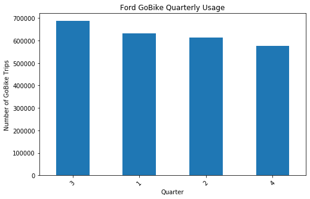

```python
plt.figure(figsize = [8, 5]);

# Code
graph_1 = df_clean['quarter'].value_counts().plot.bar()

# Graphic expression
plt.title('Ford GoBike Quarterly Usage')
plt.ylabel('Number of GoBike Trips')
plt.xlabel('Quarter')
plt.xticks(rotation = 45)
```

**01_Summary: 3rd quarter (July ~ September) has the highest Gobike demand.**

### ~~ 02: df_clean.semester

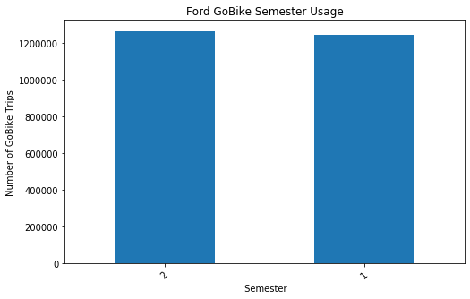

```python
plt.figure(figsize = [8, 5]);

# Code
graph_2 = df_clean['semester'].value_counts().plot.bar()

# Graphic expression
plt.title('Ford GoBike Semester Usage')
plt.ylabel('Number of GoBike Trips')
plt.xlabel(' Semester')
plt.xticks(rotation = 45)
```

**02_Summary: There is NO big differences on Gobike demand between 1st semester and 2nd semester throught the year.**

### ~~ 03: df_clean.month

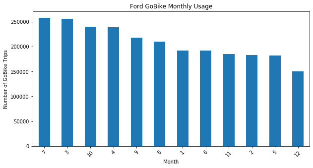

```python
plt.figure(figsize = [10, 5]);

# Code
graph_3 = df_clean['month'].value_counts().plot.bar()

# Graphic expression
plt.title('Ford GoBike Monthly Usage')
plt.ylabel('Number of GoBike Trips')
plt.xlabel('Month')
plt.xticks(rotation = 45)
```

**03_Summary: March and July are the most popular months to use the Ford GoBike system. As described above, July is the most popular month within a year, which followed by March, October and April.**

### ~~ 04: df_clean.day_of_week

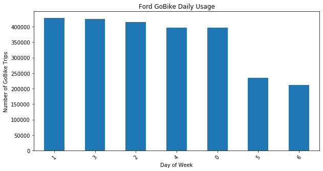

```python
plt.figure(figsize = [10, 5]);

# Code
graph_4 = df_clean['day_of_week'].value_counts().plot.bar()

# Graphic expression
plt.title('Ford GoBike Daily Usage')
plt.ylabel('Number of GoBike Trips')
plt.xlabel('Day of Week')
plt.xticks(rotation = 45)
```

**NOTE:**

**Monday: day_of_week_end = 0**

**Tuesday: day_of_week_end = 1**

**...**

**Sunday: day_of_week_end = 6**

**04_Summary: Tuesday and Thursday have the highest Gobike demand. Saturday and Sunday have the lowest Gobike demand.**

### ~~ 05: df_clean.hour

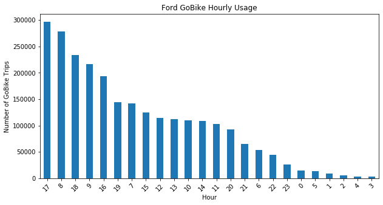

```python
plt.figure(figsize = [10, 5]);

# Code
graph_5 = df_clean['hour'].value_counts().plot.bar()

# Graphic expression
plt.title('Ford GoBike Hourly Usage')
plt.ylabel('Number of GoBike Trips')
plt.xlabel('Hour')
plt.xticks(rotation = 45)
```

**05_Summary: The most usage during a day is around 7-9am and 5-7pm. This is the time to go to work and back home in the United States. This feature suggests that the bikes are being used primarily for commuters.**

### The Second part: end time

### ~~ 01: df_clean.month_end

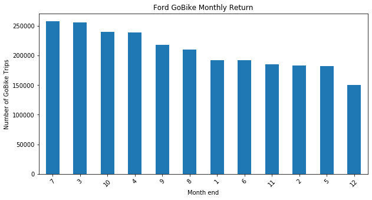

```python
# Ford GoBike system useage (Monthly)
plt.figure(figsize = [10, 5]);

# Code
graph_6 = df_clean['month_end'].value_counts().plot.bar()

# Graphic expression
plt.title('Ford GoBike Monthly Return')
plt.ylabel('Number of GoBike Trips')
plt.xlabel('Month end')
plt.xticks(rotation = 45)
```

**06_Summary: Compare to the monthly usage (start time), our Gobike system users return the bike within a month.**

### ~~ 02: df_clean.day_of_week_end

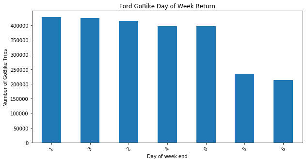

```python
plt.figure(figsize = [10, 5]);

# Code
graph_7 = df_clean['day_of_week_end'].value_counts().plot.bar()

# Graphic expression
plt.title('Ford GoBike Day of Week Return')
plt.ylabel('Number of GoBike Trips')
plt.xlabel('Day of week end')
plt.xticks(rotation = 45)
```

**NOTE:**

**Monday: day_of_week_end = 0**

**Tuesday: day_of_week_end = 1**

**...**

**Sunday: day_of_week_end = 6**

**07_Summary: Compare to the day_of_week usage (start time), our Gobike system users return the bike within a day.**

### ~~ 03: df_clean.hour_end

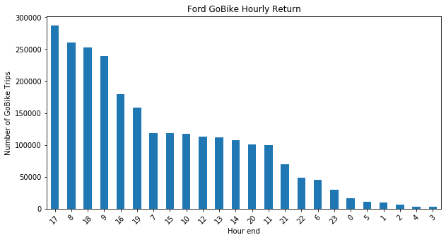

```python
plt.figure(figsize = [10,5]);

# Code
graph_8 = df_clean['hour_end'].value_counts().plot.bar()

# Graphic expression
plt.title('Ford GoBike Hourly Return')
plt.ylabel('Number of GoBike Trips')
plt.xlabel('Hour end')
plt.xticks(rotation = 45)
```

**08_Summary: Compare to the hourly usage (start time), most of the Gobike system users return the bike from 7am to 9am in the morning and 5pm to 7pm in the afternoon.**

### The Third part: Latitude & Longitude

#### -- Latitude difference and Longitude difference

```python
# Create column lat_diff
df_clean['lat_diff'] = df_clean['end_station_latitude'] - df_clean['start_station_latitude']
```

```python
# Create column long_diff
df_clean['long_diff'] = df_clean['end_station_longitude'] - df_clean['start_station_longitude']
```

```python
df_clean.info()
```

```
<class 'pandas.core.frame.DataFrame'>
RangeIndex: 2506983 entries, 0 to 2506982
Data columns (total 23 columns):
 #   Column                   Dtype
---  ------                   -----
 0   start_station_name       object
 1   start_station_latitude   float64
 2   start_station_longitude  float64
 3   end_station_name         object
 4   end_station_latitude     float64
 5   end_station_longitude    float64
 6   user_type                object
 7   bike_share_for_all_trip  object
 8   rental_access_method     object
 9   duration_min             float64
 10  quarter                  int64
 11  semester                 int64
 12  month                    int64
 13  day_of_week              int64
 14  hour                     int64
 15  quarter_end              int64
 16  semester_end             int64
 17  month_end                int64
 18  day_of_week_end          int64
 19  hour_end                 int64
 20  distance                 float64
 21  lat_diff                 float64
 22  long_diff                float64
dtypes: float64(8), int64(10), object(5)
memory usage: 439.9+ MB
```

```python
# Check the mean value of columm "lat_diff"
df_clean.lat_diff.mean()
```

```
-0.0008446880465701473
```

```python
# Check the mean value of column "long_diff"
df_clean.long_diff.mean()
```

```
0.0040116419325609675
```

**09_summary: Here again to verify the results of the more people using GoBike system just for short distance trveling.**

### The Fourth part: Popular sites

```python
# Start station
df_clean.start_station_name.value_counts()
```

```
Market St at 10th St                                         45058
Berry St at 4th St                                           42962
San Francisco Caltrain (Townsend St at 4th St)               40302
San Francisco Ferry Building (Harry Bridges Plaza)           39016
San Francisco Caltrain Station 2  (Townsend St at 4th St)    36576
                                                             ...
Prototype Lab                                                    4
San Jose Depot                                                   3
Mercado Way at Sierra Rd                                         3
Philly Demo                                                      2
SF Test Station                                                  1
Name: start_station_name, Length: 446, dtype: int64
```

```python
# End station
df_clean.end_station_name.value_counts()
```

```
San Francisco Caltrain Station 2  (Townsend St at 4th St)    52146
San Francisco Caltrain (Townsend St at 4th St)               50943
San Francisco Ferry Building (Harry Bridges Plaza)           48180
Montgomery St BART Station (Market St at 2nd St)             47886
Market St at 10th St                                         44284
                                                             ...
Howard workshop - Station in a Box                               4
Prototype Lab                                                    4
Philly Demo                                                      2
San Jose Depot                                                   2
Emeryville Depot                                                 1
Name: end_station_name, Length: 446, dtype: int64
```

**10_Summary: Most of the GoBike system user are around San Francisco Caltrain Station 2, San Francisco Ferry Building and San Francisco Caltrain.**

### The Fifth part: Delete start_station_name & end_station_name

```python
# Delete column start_station_name
df_clean = df_clean.drop(columns=['start_station_name'])
```

```python
# Delete column end_station_name
df_clean = df_clean.drop(columns=['end_station_name'])
```

```python
df_clean.info()
```

```
<class 'pandas.core.frame.DataFrame'>
RangeIndex: 2506983 entries, 0 to 2506982
Data columns (total 21 columns):
 #   Column                   Dtype
---  ------                   -----
 0   start_station_latitude   float64
 1   start_station_longitude  float64
 2   end_station_latitude     float64
 3   end_station_longitude    float64
 4   user_type                object
 5   bike_share_for_all_trip  object
 6   rental_access_method     object
 7   duration_min             float64
 8   quarter                  int64
 9   semester                 int64
 10  month                    int64
 11  day_of_week              int64
 12  hour                     int64
 13  quarter_end              int64
 14  semester_end             int64
 15  month_end                int64
 16  day_of_week_end          int64
 17  hour_end                 int64
 18  distance                 float64
 19  lat_diff                 float64
 20  long_diff                float64
dtypes: float64(8), int64(10), object(3)
memory usage: 401.7+ MB
```

### Univariate Exploration Summary

- March and July are the most popular months to use the Ford GoBike system.
- Tuesday and Thursday have the highest Gobike demand. Saturday and Sunday have the lowest Gobike demand.
- The most usage during a day is around 8am and 5pm. This is the time to go to work and back home in the United States.
- Most of the Gobike system users return the bike within a day.
- Using latitude differences and longitude differences to verify the results of the more people using GoBike system just for short distance trveling.
- Most of the GoBike system user are around San Francisco Caltrain Station 2, San Francisco Ferry Building and San Francisco Caltrain.

## Bivariate Exploration

### In this section, I investigate distributions between two variables.

```python
df_clean.head()
```

|  | start_station_latitude | start_station_longitude | end_station_latitude | end_station_longitude | user_type | bike_share_for_all_trip | rental_access_method | duration_min | quarter | semester | ... | day_of_week | hour | quarter_end | semester_end | month_end | day_of_week_end | hour_end | distance | lat_diff | long_diff |
| --- | --- | --- | --- | --- | --- | --- | --- | --- | --- | --- | --- | --- | --- | --- | --- | --- | --- | --- | --- | --- | --- |
| 0 | 37.775745 | -122.213037 | 37.808894 | -122.256460 | Subscriber | No | NaN | 1347.083333 | 1 | 1 | ... | 3 | 17 | 1 | 1 | 2 | 4 | 16 | 5305.0 | 0.033149 | -0.043423 |
| 1 | 37.785881 | -122.408915 | 37.752428 | -122.420628 | Subscriber | No | NaN | 1098.333333 | 1 | 1 | ... | 3 | 20 | 1 | 1 | 2 | 4 | 15 | 3860.0 | -0.033453 | -0.011713 |
| 2 | 37.870139 | -122.268422 | 37.846784 | -122.291376 | Customer | No | NaN | 1043.883333 | 1 | 1 | ... | 3 | 18 | 1 | 1 | 2 | 4 | 11 | 3287.0 | -0.023355 | -0.022954 |
| 3 | 37.770083 | -122.429156 | 37.775946 | -122.437777 | Customer | No | NaN | 744.666667 | 1 | 1 | ... | 3 | 19 | 1 | 1 | 2 | 4 | 8 | 1000.0 | 0.005863 | -0.008622 |
| 4 | 37.794130 | -122.394430 | 37.787168 | -122.388098 | Customer | No | NaN | 1011.816667 | 1 | 1 | ... | 3 | 14 | 1 | 1 | 2 | 4 | 7 | 953.0 | -0.006962 | 0.006332 |

5 rows × 21 columns

### The First part:. Correlation between variables

```python
# Check the correlation between variables
columns_name = ['start_station_latitude', 'start_station_longitude',
                'end_station_latitude','end_station_longitude',
                'duration_min', 'lat_diff', 'long_diff', 'distance']
numeric_vars = ['duration_min']
categoric_vars = ['semester', 'quarter', 'day_of_week', 'hour',
                  'user_type', 'bike_share_for_all_trip', 'rental_access_method']
```

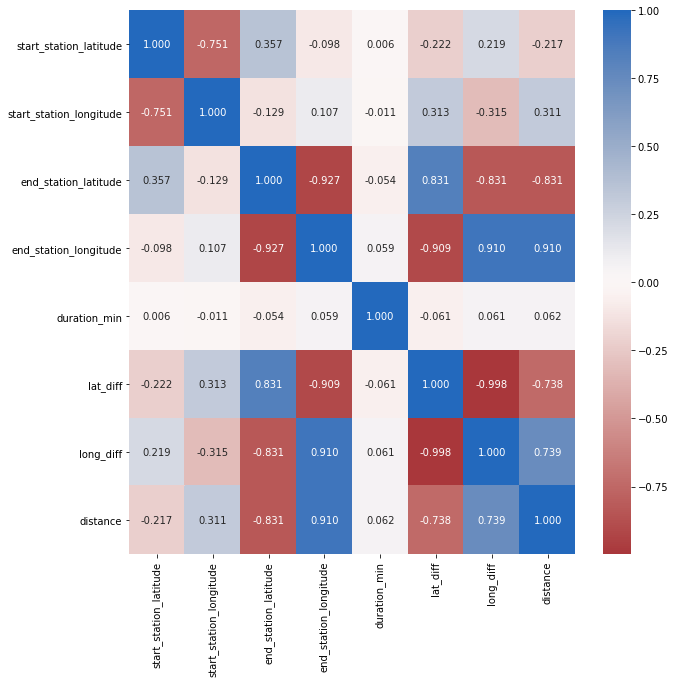

```python
# Correlation plot
plt.figure(figsize = [10, 10])
sb.heatmap(df_clean[columns_name].corr(), annot = True, fmt = '.3f', cmap = 'vlag_r', center = 0);
```

**11_Summary: The cofficients indicate that there might be correlations between the following pairs of variables:**

**(A). start_station_latitude & start_station_longitude**

**(B). start_station_longitude & start_station_latitude**

**(C). start_station_latitude & end_station_latitude**

**(D). end_station_latitude & start_station_latitude**

**(E). end_station_longitude & end_station_latitude**

**(F). end_station_longitude & end_station_latitude**

**(G). lat_diff & end_station latitude**

**(H). long_diff & end_station_latitude**

**(I). distance & end_station_latitude**

**(J). lat_diff & end_station_longitude**

**(K). long_diff & end_station_longitude**

**(L). distance & end_station_longitude**

**(M). long_diff & lat_diff**

**(N). distance & lat_diff**

**(O). distance & long_diff**

### The Second part: Subscriber & Customer

```python
# Check user_types
df_clean.user_type.value_counts()
```

```
Subscriber    2021166
Customer       485817
Name: user_type, dtype: int64
```

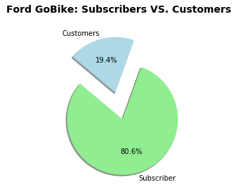

```python
# Pie Chart
# Data to plot
labels = ['Subscriber', 'Customers']
sizes = [2021166, 485817]
colors = ['lightgreen', 'lightblue']
explode = (0, 0.5)  # explode 1st slice

# Plot
plt.pie(sizes, explode = explode, labels = labels, colors = colors, autopct = '%1.1f%%', shadow = True, startangle = 140)
plt.axis('equal')
plt.suptitle('Ford GoBike: Subscribers VS. Customers', y = 1.00, fontsize = 14, fontweight = 'bold');
plt.show()
```

### The Third part: Bike share for all trip

```python
# Check data groups
df_clean.bike_share_for_all_trip.value_counts()
```

```
No     2086152
Yes     177572
Name: bike_share_for_all_trip, dtype: int64
```

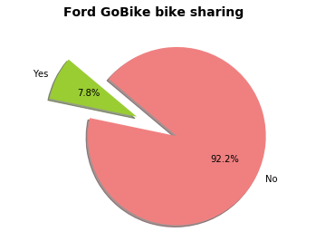

```python
# Pie Chart
# Data to plot
labels = ['Yes', 'No']
sizes = [177572, 2086152]
colors = ['yellowgreen', 'lightcoral']
explode = (0, 0.5)  # explode 1st slice

# Plot
plt.pie(sizes, explode = explode, labels = labels, colors = colors, autopct = '%1.1f%%', shadow = True, startangle = 140)
plt.axis('equal')
plt.suptitle('Ford GoBike bike sharing', y = 1.00, fontsize = 14, fontweight = 'bold');
plt.show()
```

### The Fourth part: App & Clipper

```python
# Check data groups
df_clean.rental_access_method.value_counts()
```

```
app        108010
clipper     12828
Name: rental_access_method, dtype: int64
```

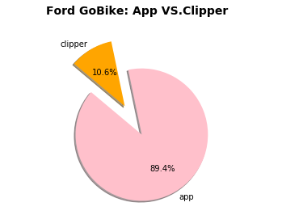

```python
# Pie Chart
# Data to plot
labels = ['app', 'clipper']
sizes = [108010, 12828]
colors = ['pink', 'orange']
explode = (0, 0.5)  # explode 1st slice

# Plot
plt.pie(sizes, explode = explode, labels = labels, colors = colors, autopct = '%1.1f%%', shadow = True, startangle = 140)
plt.axis('equal')
plt.suptitle('Ford GoBike: App VS.Clipper', y = 1.00, fontsize = 14, fontweight = 'bold');
plt.show()
```

### The Fifth part: Hour (start time) and other variables

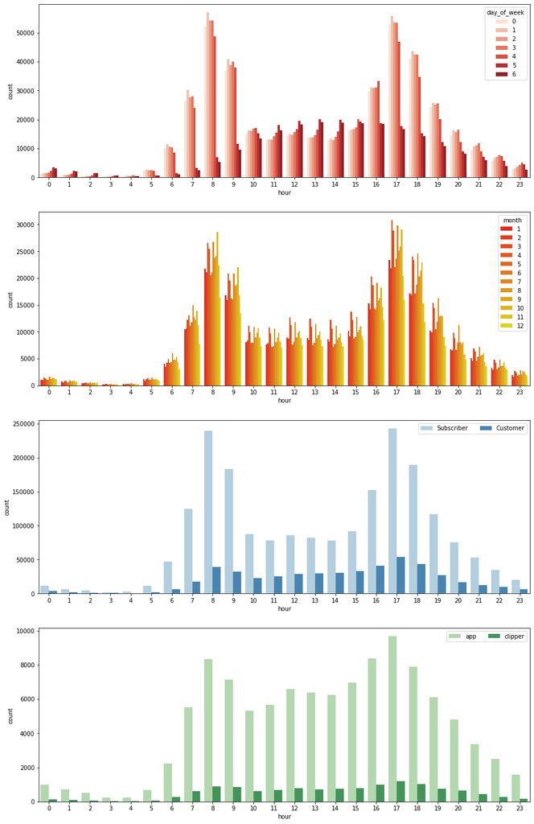

```python
plt.figure(figsize = [15, 25]);

# start time hour & day
x_1 = plt.subplot(4, 1, 1);
sb.countplot(data = df_clean, x = 'hour', hue = 'day_of_week', palette = 'Reds');

# start time hour & Month
x_2 = plt.subplot(4, 1, 2);
sb.countplot(data = df_clean, x = 'hour', hue = 'month', palette = 'autumn');

# start time hour & User type
x_3 = plt.subplot(4, 1, 3);
sb.countplot(data = df_clean, x = 'hour', hue = 'user_type', palette = 'Blues');
# re-arrange to remove overlapping
x_3.legend(loc = 1, ncol = 2);

# start time hour & Rental Access Method
x_4 = plt.subplot(4, 1, 4);
sb.countplot(data = df_clean, x = 'hour', hue = 'rental_access_method', palette = 'Greens');
# re-arrange to remove overlapping
x_4.legend(loc = 1, ncol = 2);
```

**12_Summary:**

**(A). 8am in the morning and 5pm in the afternoon has the highest GoBike usage in week days.**

**(B). July has the highest number of GoBike trips.**

**(C). 5pm in the afternoon has the most subscriber and customer bikers.**

**(E). Around 5pm in the afternoon has the highest rental demand through app and clipper.**

### The Sixth part: User type in different time periods

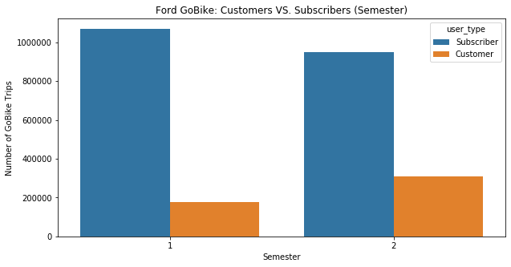

```python
# Relationship between Subscriber & Customer
# Semester
plt.figure(figsize = [10, 5])

# Code
graph_9 = sb.countplot(data = df_clean, x = 'semester', hue = "user_type");

# Graphic expression
plt.title('Ford GoBike: Customers VS. Subscribers (Semester)')
plt.ylabel('Number of GoBike Trips')
plt.xlabel('Semester')
```

**13_Summary: There are more subscriber users compare to customers for both semesters.**

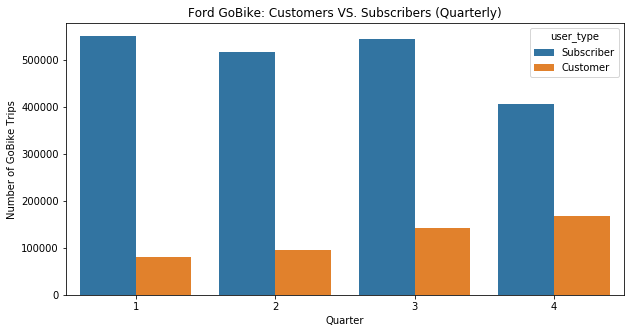

```python
# Relationship between Subscriber & Customer
# Quarterly
plt.figure(figsize = [10, 5])

# Code
graph_10 = sb.countplot(data = df_clean, x = 'quarter', hue = "user_type");

# Graphic expression
plt.title('Ford GoBike: Customers VS. Subscribers (Quarterly)')
plt.ylabel('Number of GoBike Trips')
plt.xlabel('Quarter')
```

**14_Summary: Although the number of subscribers is still higher than the number of customers throughout the year, the number of customers increased significantly in the second half of the year.**

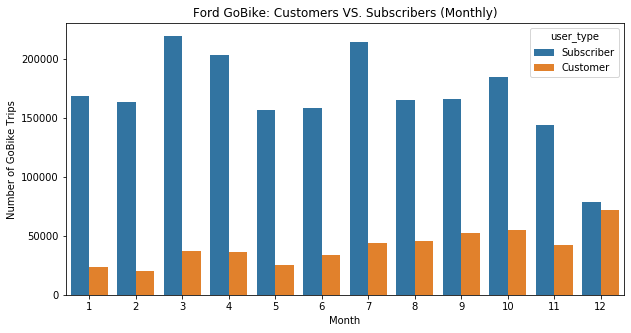

```python
# Relationship between Subscriber & Customer
# Monthly
plt.figure(figsize = [10, 5])

# Code
graph_11 = sb.countplot(data = df_clean, x = 'month', hue = "user_type");

# Graphic expression
plt.title('Ford GoBike: Customers VS. Subscribers (Monthly)')
plt.ylabel('Number of GoBike Trips')
plt.xlabel('Month')
```

**Customers (19.4%):** **The bar chart above shows that more tourists choose to come for vacation in the second half of the year. GoBike usage reaching its peak in December.**

**Subscribers(80.6%):** **More subscribers need rides in March and July. In December, subscribers’ demand for bicycles was significantly reduced by half. Subscribers are most probably riders who using the bikes for their daily routine.**

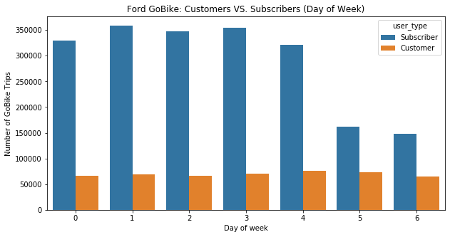

```python
# Relationship between Subscriber & Customer
# Day of Week
plt.figure(figsize = [10, 5])

# Code
graph_12 = sb.countplot(data = df_clean, x = 'day_of_week', hue = "user_type");

# Graphic expression
plt.title('Ford GoBike: Customers VS. Subscribers (Day of Week)')
plt.ylabel('Number of GoBike Trips')
plt.xlabel('Day of week')
```

**NOTE:**

**Monday: day_of_week_end = 0**

**Tuesday: day_of_week_end = 1**

**...**

**Sunday: day_of_week_end = 6**

**16_Summary: The demand for bicycles is almost the same for customers. However, there will be more subcribers who generally need bicycles during workdays**

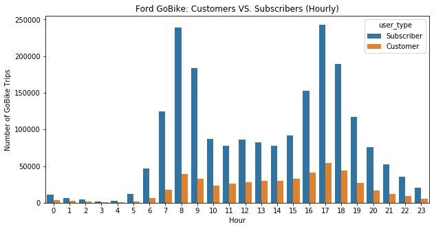

```python
# Relationship between Subscriber & Customer
# Hour
plt.figure(figsize = [10, 5])

# Code
graph_13 = sb.countplot(data = df_clean, x = 'hour', hue = "user_type");

# Graphic expression
plt.title('Ford GoBike: Customers VS. Subscribers (Hourly)')
plt.ylabel('Number of GoBike Trips')
plt.xlabel('Hour')
```

**17_Summary: Interestingly, subscribers and customers prefer to use bicycles around 8am in the morning and around 5pm in the afternoon.**

### The Seventh part: Rental access method in different time periods

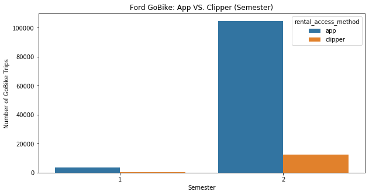

```python
# Relationship between App & Clipper
# Semester
plt.figure(figsize = [10, 5])

# Code
graph_14 = sb.countplot(data = df_clean, x = 'semester', hue = "rental_access_method");

# Graphic expression
plt.title('Ford GoBike: App VS. Clipper (Semester)')
plt.ylabel('Number of GoBike Trips')
plt.xlabel('Semester')
```

**18_Summary: Almost all leases are in the second half of the year. Most of them will choose to use the app to rent bicycles.**

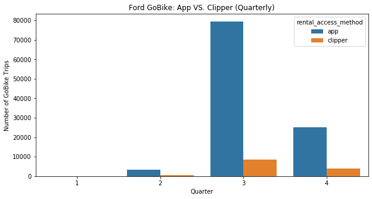

```python
# Relationship between App & Clipper
# Quarterly
plt.figure(figsize = [10, 5])

# Code
graph_15 = sb.countplot(data = df_clean, x = 'quarter', hue = "rental_access_method");

# Graphic expression
plt.title('Ford GoBike: App VS. Clipper (Quarterly)')
plt.ylabel('Number of GoBike Trips')
plt.xlabel('Quarter')
```

**19_Summary: From the above figure, it is not difficult to see that the demand for bicycle rental in the third quarter was much higher than all the rest of the time. And Gobike system users generally chooses to use the app to rent.**

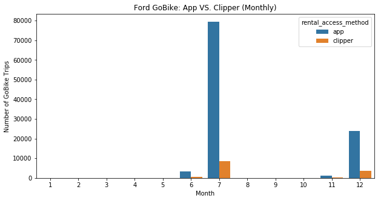

```python
# Relationship between App & Clipper
# Monthly
plt.figure(figsize = [10, 5])

# Code
graph_16 = sb.countplot(data = df_clean, x = 'month', hue = "rental_access_method");

# Graphic expression
plt.title('Ford GoBike: App VS. Clipper (Monthly)')
plt.ylabel('Number of GoBike Trips')
plt.xlabel('Month')
```

**20_Summary: To be more precise, application rentals in July can reach 70% of a yearly rental. It can be seen that the number of trips in July should be higher than in other months.**

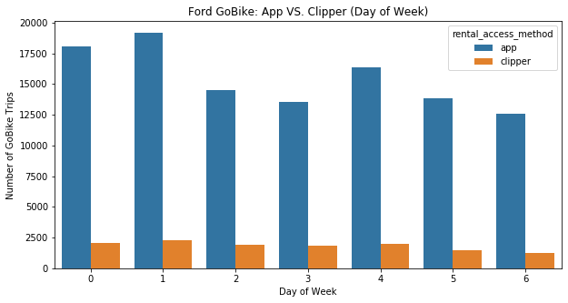

```python
# Relationship between App & Clipper
# Day of Week
plt.figure(figsize = [10, 5])

# Code
graph_17 = sb.countplot(data = df_clean, x = 'day_of_week', hue = "rental_access_method");

# Graphic expression
plt.title('Ford GoBike: App VS. Clipper (Day of Week)')
plt.ylabel('Number of GoBike Trips')
plt.xlabel('Day of Week')
```

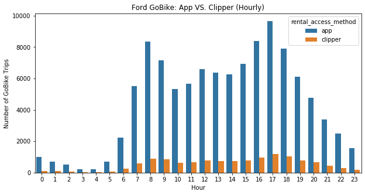

```python
# Relationship between App & Clipper
# Hourly
plt.figure(figsize = [10, 5])

# Code
graph_18 = sb.countplot(data = df_clean, x = 'hour', hue = "rental_access_method");

# Graphic expression
plt.title('Ford GoBike: App VS. Clipper (Hourly)')
plt.ylabel('Number of GoBike Trips')
plt.xlabel('Hour')
```

**22_Summary: The hourly rental demand here more shows the hourly demand in July as well. Same as above, both app and clipper rental demand would reach its peak around 8am and 5pm.**

### The Eighth part: Bike share in different time periods

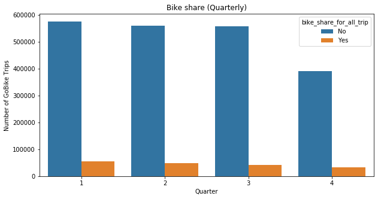

```python
# Quarterly
plt.figure(figsize = [10, 5])

# Code
graph_19 = sb.countplot(data = df_clean, x = 'quarter', hue = "bike_share_for_all_trip");

# Graphic expression
plt.title('Bike share (Quarterly)')
plt.ylabel('Number of GoBike Trips')
plt.xlabel('Quarter')
```

**23_Summary: Only a few users choose to share bicycles with others. Bike sharing occurred more often in the first quarter.**

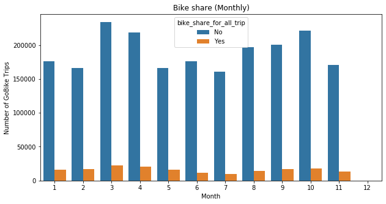

```python
# Monthly
plt.figure(figsize = [10, 5])

# Code
graph_20 = sb.countplot(data = df_clean, x = 'month', hue = "bike_share_for_all_trip");

# Graphic expression
plt.title('Bike share (Monthly)')
plt.ylabel('Number of GoBike Trips')
plt.xlabel('Month')
```

**24_Summary: To be more precise, bike sharing situation reached its peak in March.**

## Multivariate Exploration

### In this section, I investigate distributions for more than two variables.

### The First part: How does user type affected by the GoBike system in different time periods

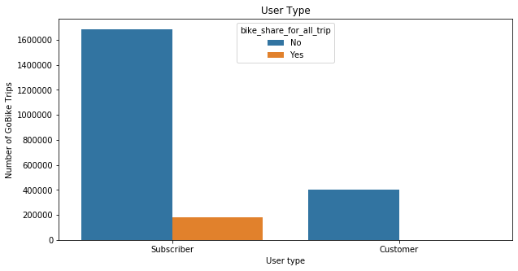

```python
# Illustrate user type using bar chart
plt.figure(figsize = [10, 5])

# Code
graph_21 = sb.countplot(data = df_clean, x = "user_type", hue = "bike_share_for_all_trip",
                        order = df_clean.user_type.value_counts().index)

# Graphic expression
plt.title('User Type')
plt.ylabel('Number of GoBike Trips')
plt.xlabel('User type')
```

**25_Summary: Bike share ONLY happens on Subscribers**

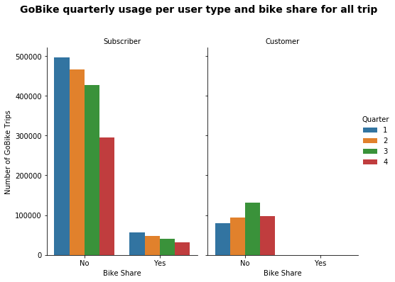

```python
# Quarterly effect
plt.figure(figsize = [150, 100])

# Code
graph_22 = sb.catplot(data = df_clean, x = "bike_share_for_all_trip",hue = 'quarter', col = "user_type",
                      kind = 'count', height = 5, aspect = 0.7)

# Graphic expression
graph_22._legend.set_title('Quarter')
graph_22.set_axis_labels("Bike Share", "Number of GoBike Trips")
graph_22.set_titles("{col_name}")
graph_22.fig.suptitle('GoBike quarterly usage per user type and bike share for all trip',
                      y = 1.10, fontsize = 14, fontweight = 'semibold');
```

**26_Summary: Although only a small percentage of people choose to share bicycles, these people prefer to share bicycles with others in the first quarter.**

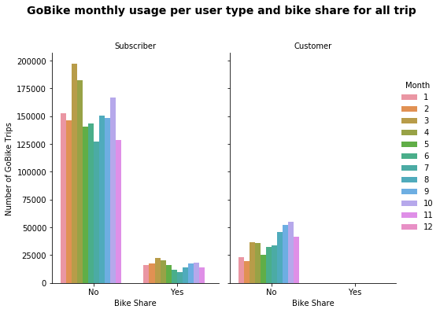

```python
# Monthly effect
plt.figure(figsize = [150, 100])

# Code
graph_23 = sb.catplot(data = df_clean, x = "bike_share_for_all_trip",hue = 'month', col = "user_type",
                      kind = 'count', height = 5, aspect = 0.7)

# Graphic expression
graph_23._legend.set_title('Month')
graph_23.set_axis_labels("Bike Share", "Number of GoBike Trips")
graph_23.set_titles("{col_name}")
graph_23.fig.suptitle('GoBike monthly usage per user type and bike share for all trip',
                      y = 1.10, fontsize = 14, fontweight = 'semibold');
```

**27_Summary: The trend is quite different for subscriber and customer: Suprisingly, there is NO customers using bike sharing system. It might because customers only use Ford GoBike system for tourists. They return the bike once arrive their distination. As for subscribers, there are part of the subcribers choose bike sharing in each month, especially in March.**

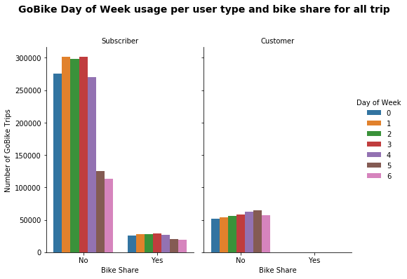

```python
# Day of week effect
plt.figure(figsize = [150, 100])

# Code
graph_24 = sb.catplot(data = df_clean, x = "bike_share_for_all_trip",hue = 'day_of_week', col = "user_type",
                      kind = 'count', height = 5, aspect = 0.7)

# Graphic expression
graph_24._legend.set_title('Day of Week')
graph_24.set_axis_labels("Bike Share", "Number of GoBike Trips", )
graph_24.set_titles("{col_name}")
graph_24.fig.suptitle('GoBike Day of Week usage per user type and bike share for all trip',
                      y = 1.10, fontsize = 14, fontweight = 'semibold');
```

**NOTE:**

**Monday: day_of_week_end = 0**

**Tuesday: day_of_week_end = 1**

**...**

**Sunday: day_of_week_end = 6**

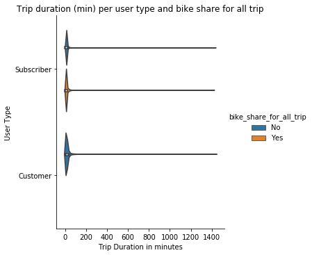

```python
# Violinplot duration (min) distribution per user type and bike sharing

# Code
graph_25 = sb.catplot(data = df_clean, x = "duration_min",  y = 'user_type', hue = "bike_share_for_all_trip",
                      kind="violin", height = 5)

# Graphic expression
plt.title('Trip duration (min) per user type and bike share for all trip')
plt.ylabel('User Type')
plt.xlabel('Trip Duration in minutes')
plt.show();
```

**29_Summary: The graph illustrates that more people use Gobike sharing systems for short distance traveling.**

### The Second part: How does latitude travel difference different among user type in the GoBike system in different time periods

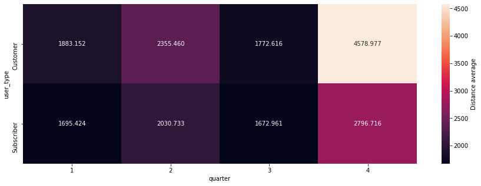

```python
# Quarterly effect
plt.figure(figsize = [15, 5])

graph_26 = df_clean.groupby(['quarter', 'user_type']).mean()['distance']
graph_26 = graph_26.reset_index(name = 'distance_average')
graph_26 = graph_26.pivot(index = 'user_type', columns = 'quarter',
                            values = 'distance_average')
sb.heatmap(graph_26, annot = True, fmt = '.3f',
           cbar_kws = {'label' : 'Distance average'})
```

**30_Summary: Both subscribers and customers usually choose to travel relatively far in the fourth quarter.**

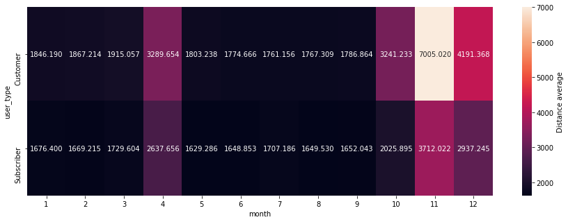

```python
# Monthly effect
plt.figure(figsize = [15, 5])

graph_27 = df_clean.groupby(['month', 'user_type']).mean()['distance']
graph_27 = graph_27.reset_index(name = 'distance_average')
graph_27 = graph_27.pivot(index = 'user_type', columns = 'month',
                            values = 'distance_average')
sb.heatmap(graph_27, annot = True, fmt = '.3f',
           cbar_kws = {'label' : 'Distance average'})
```

**31_Summary: To be more precise, travel distances are generally longer in November. This may be because the company will have more business trips at the end of the year, and travelers choose to take a vacation after finishing a year of planning.**

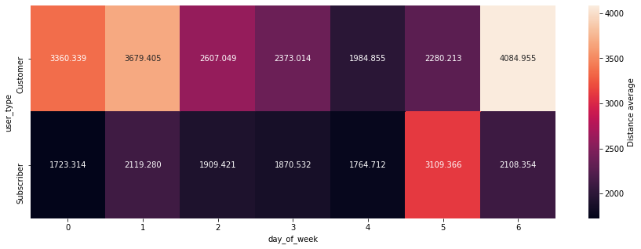

```python
# Day of week effect
plt.figure(figsize = [15, 5])

graph_28 = df_clean.groupby(['day_of_week', 'user_type']).mean()['distance']
graph_28 = graph_28.reset_index(name = 'distance_average')
graph_28 = graph_28.pivot(index = 'user_type', columns = 'day_of_week',
                            values = 'distance_average')
sb.heatmap(graph_28, annot = True, fmt = '.3f',
           cbar_kws = {'label' : 'Distance average'})
```

**NOTE:**

**Monday: day_of_week_end = 0**

**Tuesday: day_of_week_end = 1**

**...**

**Sunday: day_of_week_end = 6**

**32_Summary: Since subscribers ride the farthest journey on Saturday, we can reasonably guess that after completing a week of office work, they will choose to travel on Saturday to communicate the annual summary with others.**

### Multivariate Exploration Summary

- Bike share ONLY happens on Subscribers. Although only a small percentage of people choose to share bicycles, these people prefer to share bicycles with others in the first quarter.
- The trend is quite different for subscriber and customer. There is NO customers using bike sharing system. It might because customers only use Ford GoBike system for tourists. They return the bike once arrive their distination. As for subscribers, there are part of the subcribers choose bike sharing in each month, especially in March.
- Both subscribers and customers usually choose to travel relatively far in the fourth quarter. To be more precise, travel distances are generally longer in November. This may be because the company will have more business trips at the end of the year, and travelers choose to take a vacation after finishing a year of planning.

## Summary

Ford GoBike System is an innovative project, which provides bike-renting service for moving around in the city, both for work and travel.

**There are two types of users:** Subscribers and Customers.

**There are two rental methods:** App and Clipper.

**Subscribers (80.6%)** are primarily using GoBike system for daily commute. (Short distance traveling)

**Customers (19.4%)** are usually tourists who use the GoBike system to explore the Bay Area.

**App:** 90% of the clients prefer to rent bikes through the app.

**Average traveling distance:** Travel distances are generally longer in November. This may due to more business trips at the end of the year, and travelers choose to take a vacation after finishing a year of planning.